# DV HW 4

Ming Nie

4/2/2021

Network Analysis of U.S. Senate Tweets Overview Twitter is a great tool to analyze the public interactions of political actors. For this assignment, I want you to use the information about who follows whom on Twitter as well as past tweets of the current U.S. Senate members to analyze how they interact and what they tweet about.

Data Twitter Handles of Senators Twitter does not allow us to search for past tweets (beyond about a week back) based on keywords, location, or topics (hashtags). However, we are able to obtain the past tweets of users if we specify their Twitter handle. The file senators_twitter.csv contains the Twitter handles of the current U.S. Senate members (obtained from UCSD library). We will focus on the Senators’ official Twitter accounts (as opposed to campaign or staff members). The data also contains information on the party affiliation of the Senators.

Followers The file senators_follow.csv contains an edge list of connections between each pair of senators who are connected through a follower relationship (this information was obtained using the function rtweet::lookup_friendships). The file is encoded such that the source is a follower of the target. You will need to use the subset of following = TRUE to identify the connections for which the source follows the target.

Tweets by Senators To make your life a bit easier, I have also already downloaded all available tweets for these Twitter accounts using the following code. You do not need to repeat this step. Simply rely on the file senator_tweets.RDS in the exercise folder.

The data contains about 280k tweets and about 90 variables. Please note, that the API limit of 3,200 tweets per twitter handle actually cuts down the time period we can observe the most prolific Twitter users in the Senate down to only about one year into the past.

Tasks for the Assignment 1. Who follows whom? a) Network of Followers Read in the edgelist of follower relationships from the file senators_follow.csv.

```r
setwd("D:/Github/Nie_Ming/assignment 4")
d = read.csv("senators_follow.csv")
d_tw = read.csv("senators_twitter.csv")
head(d)
```

```
##           source          target following followed_by
## 1 SenatorBaldwin  SenatorBaldwin     FALSE       FALSE
## 2 SenatorBaldwin SenJohnBarrasso     FALSE        TRUE
## 3 SenatorBaldwin   SenatorBennet      TRUE        TRUE
## 4 SenatorBaldwin MarshaBlackburn     FALSE       FALSE
## 5 SenatorBaldwin   SenBlumenthal      TRUE        TRUE
## 6 SenatorBaldwin        RoyBlunt     FALSE        TRUE
```

```r
head(d_tw)
```

```
##               senator  twitter_handle state party
## 1      Baldwin, Tammy  SenatorBaldwin    WI     D
## 2      Barrasso, John SenJohnBarrasso    WY     R
## 3  Bennet, Michael F.   SenatorBennet    CO     D
## 4   Blackburn, Marsha MarshaBlackburn    TN     R
## 5 Blumenthal, Richard   SenBlumenthal    CT     D
## 6          Blunt, Roy        RoyBlunt    MO     R
```

Create a directed network graph.

```r
net <- d %>% select(source, target, following) %>% filter(following ==TRUE)
gr <- graph_from_data_frame(d = net, directed = TRUE)
V(gr)$size <- centralization.degree(gr)$res
E(gr)$weight <- 1
g <- igraph::simplify(gr, edge.attr.comb="sum")

set.seed(2103)
dat <- ggnetwork(g,
          layout=igraph::with_fr(),
          )
```

```r
gg1 <- ggplot() +
  geom_edges(data=dat,
             aes(x=x, y=y, xend=xend, yend=yend)) +
  geom_nodes(data=dat,
             aes(x=x, y=y, xend=xend, yend=yend))
dat_top <- dat %>% distinct(name, .keep_all = TRUE)
dat<- left_join(dat_top,d_tw, by = c("name" = "twitter_handle"))
```

Identify the three senators who are followed by the most of their colleagues (i.e. the highest “in-degree”) and the three senators who follow the most of their colleagues (i.e. the highest “out-degree”). [Hint: You can get this information simply from the data frame or use igraph to calculate the number of in and out connections: indegree = igraph::degree(g, mode = “in”).]

```r
indegree = igraph::degree(g, mode = "in")
head(sort(indegree, decreasing = TRUE))
```

```
##   SenRonJohnson   SenatorRomney SenatorLankford   SenatorHassan SenatorCantwell
##              93              92              91              90              89
##    SenRickScott
##              89
```

```r
outdegree = igraph::degree(g, mode = "out")
head(sort(outdegree, decreasing = TRUE))
```

```
## SenatorCollins  lisamurkowski  ChuckGrassley Sen_JoeManchin       RoyBlunt
##             83             80             76             76             73
##     JohnCornyn
##             73
```

Answer:

top3 by indegree: SenRonJohnson SenatorRomney SenatorLankford

top3 by outdegree: SenatorCollins lisamurkowski ChuckGrassley

Visualize the network of senators. In the visualization, highlight the party ID of the senator nodes with an appropriate color (blue = Democrat, red = Republican) and size the nodes by the centrality of the nodes to the network. Briefly comment.

color (blue = Democrat, red = Republican)

COMMENT: dems and reps are separated. We can see the two independent senators interact more with dems. Nodes in the central area are bigger for larger centrality.

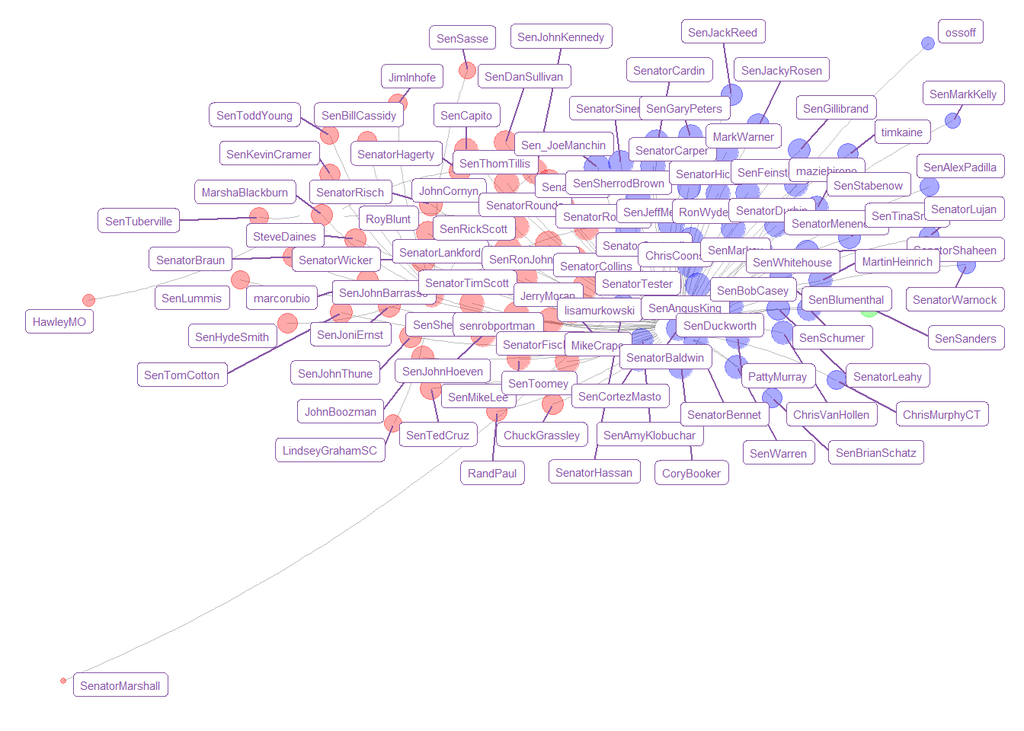

```r
(gg2 <- ggplot() +
    geom_edges(data=dat,
               aes(x=x, y=y, xend=xend, yend=yend),
               color="grey50", curvature=0.1, size=0.15, alpha=1/2) +
    geom_nodes(data=dat,
               aes(x=x, y=y, xend=xend, yend=yend,
                   size=size,color = party),
               alpha=1/3) +
    geom_label_repel(data=dat_top, max.overlaps = 100,
                     aes(x=x, y=y, label=name),
                     size=2, color="#8856a7") +
  scale_colour_manual(values = c("D" = "blue", "R" = "red","I"="green"))+
    theme_blank() +
    theme(legend.position="none") )
```

2. Communities Now let’s see whether party identification is also recovered by an automated mechanism of cluster identification. Use the cluster_walktrap command in the igraph package to find densely connected subgraphs.

Based on the results, visualize how well this automated community detection mechanism recovers the party affiliation of senators. This visualization need not be a network graph. Comment briefly.

Comment:The cluster_walktrap command did a great job in separating the senator by party affiliation. BUt the plot is unable to identify the independent senator.

```r
net2 <- d %>% select(source, target, following) %>% filter(following ==TRUE)
net2<- left_join(net2,d_tw, by = c("source" = "twitter_handle"))

gr2 <- graph_from_data_frame(d = net2, directed = TRUE)

wc <- cluster_walktrap(gr2)
members <- membership(wc)

group_sen <- igraph_to_networkD3(gr2, group=members)

(ip2 <- forceNetwork(Links = group_sen$links, Nodes = group_sen$node,
                  Source = 'source', Target = 'target',
                  NodeID = 'name',
                  Group = 'group', # color nodes by group calculated earlier
                  charge = -50, # node repulsion
                  linkDistance = 20,
                  zoom = T,
                  opacity = 1,
                  fontSize=24))
```

[interactive chart not shown]

2. What are they tweeting about? From now on, rely on the information from the tweets stored in senator_tweets.RDS.
1. Most Common Topics over Time Remove all tweets that are re-tweets (is_retweet) and identify which topics the senators tweet about. Rather than a full text analysis, just use the variable hashtags and identify the most common hashtags over time. Provide a visual summary.

```r
setwd("D:/Github/Nie_Ming/assignment 4")
# Read in the Tweets
dt <- readRDS("senator_tweets.RDS")
head(dt)
```

```
## # A tibble: 6 x 90
##   user_id status_id created_at          screen_name text  source
##   <chr>   <chr>     <dttm>              <chr>       <chr> <chr>
## 1 107451~ 13776841~ 2021-04-01 18:07:58 SenatorBal~ "Go ~ Twitt~
## 2 107451~ 13776569~ 2021-04-01 16:19:37 SenatorBal~ "Sen~ Twitt~
## 3 107451~ 13776483~ 2021-04-01 15:45:26 SenatorBal~ "The~ Twitt~
## 4 107451~ 13776452~ 2021-04-01 15:33:23 SenatorBal~ "We ~ Twitt~
## 5 107451~ 13773495~ 2021-03-31 19:58:22 SenatorBal~ "We ~ Twitt~
## 6 107451~ 13773254~ 2021-03-31 18:22:42 SenatorBal~ "On ~ Twitt~
## # ... with 84 more variables: display_text_width <dbl>,
## #   reply_to_status_id <chr>, reply_to_user_id <chr>,
## #   reply_to_screen_name <chr>, is_quote <lgl>, is_retweet <lgl>,
## #   favorite_count <int>, retweet_count <int>, quote_count <int>,
## #   reply_count <int>, hashtags <list>, symbols <list>, urls_url <list>,
## #   urls_t.co <list>, urls_expanded_url <list>, media_url <list>,
## #   media_t.co <list>, media_expanded_url <list>, media_type <list>,
## #   ext_media_url <list>, ext_media_t.co <list>, ext_media_expanded_url <list>,
## #   ext_media_type <chr>, mentions_user_id <list>, mentions_screen_name <list>,
## #   lang <chr>, quoted_status_id <chr>, quoted_text <chr>,
## #   quoted_created_at <dttm>, quoted_source <chr>, quoted_favorite_count <int>,
## #   quoted_retweet_count <int>, quoted_user_id <chr>, quoted_screen_name <chr>,
## #   quoted_name <chr>, quoted_followers_count <int>,
## #   quoted_friends_count <int>, quoted_statuses_count <int>,
## #   quoted_location <chr>, quoted_description <chr>, quoted_verified <lgl>,
## #   retweet_status_id <chr>, retweet_text <chr>, retweet_created_at <dttm>,
## #   retweet_source <chr>, retweet_favorite_count <int>,
## #   retweet_retweet_count <int>, retweet_user_id <chr>,
## #   retweet_screen_name <chr>, retweet_name <chr>,
## #   retweet_followers_count <int>, retweet_friends_count <int>,
## #   retweet_statuses_count <int>, retweet_location <chr>,
## #   retweet_description <chr>, retweet_verified <lgl>, place_url <chr>,
## #   place_name <chr>, place_full_name <chr>, place_type <chr>, country <chr>,
## #   country_code <chr>, geo_coords <list>, coords_coords <list>,
## #   bbox_coords <list>, status_url <chr>, name <chr>, location <chr>,
## #   description <chr>, url <chr>, protected <lgl>, followers_count <int>,
## #   friends_count <int>, listed_count <int>, statuses_count <int>,
## #   favourites_count <int>, account_created_at <dttm>, verified <lgl>,
## #   profile_url <chr>, profile_expanded_url <chr>, account_lang <lgl>,
## #   profile_banner_url <chr>, profile_background_url <chr>,
## #   profile_image_url <chr>
```

```r
hash <- dt %>% filter(is_retweet == FALSE) %>% group_by(hashtags) %>% dplyr::summarise(count = n()) %>%  arrange(desc(count)) %>% top_n(100)
```

The hashtags popular over time.

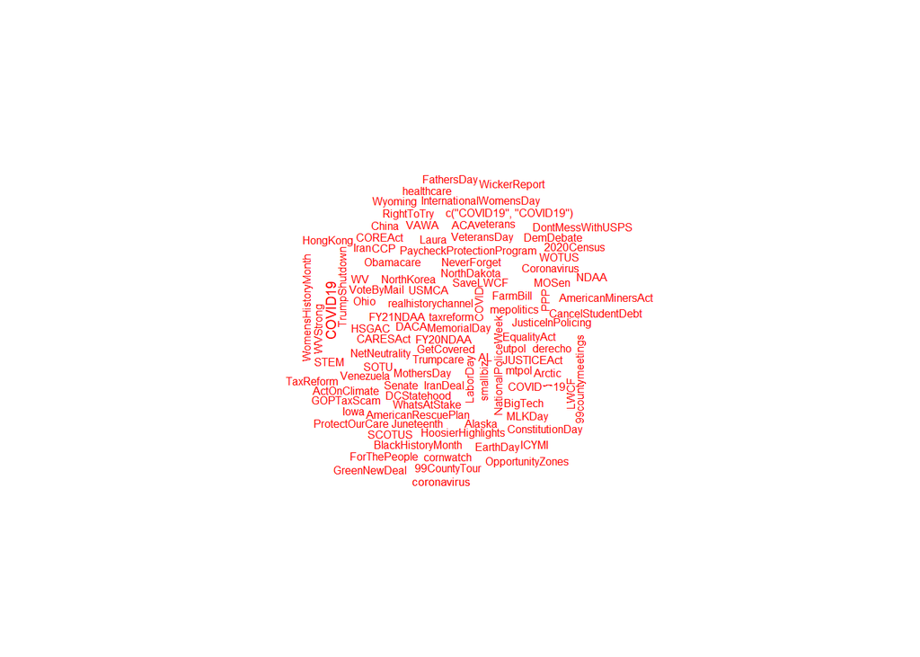

```r
wordcloud(hash$hashtags, hash$count,
         max.words = 100, colors = "red")
```

2. BONUS ONLY: Election Fraud 2020 - Dems vs. Reps One topic that did receive substantial attention in the recent past the issue whether the [2020 presidential election involved fraud] and should be overturned. The resulting far-right and conservative campaign to Stop the Steal promoted the conspiracy theory that falsely posited that widespread electoral fraud occurred during the 2020 presidential election to deny incumbent President Donald Trump victory over former vice president Joe Biden.

Try to identify a set of 5-10 hashtags that signal support for the movement (e.g. #voterfraud, #stopthesteal, #holdtheline, #trumpwon, #voterid) while other expressed a critical sentiment towards the protest (e.g. #trumplost).

Sites like hashtagify.me or ritetag.com can help with that task. Using the subset of senator tweets that included these hashtags you identified, show whether and how senators from different parties talk differently about the issue of the 2020 election outcome.

3. Are you talking to me? Often tweets are simply public statements without addressing a specific audience. However, it is possible to interact with a specific person by adding them as a friend, becoming their follower, re-tweeting their messages, and/or mentioning them in a tweet using the @ symbol.
1. Identifying Re-Tweets Select the set of re-tweeted messages from other senators and identify the source of the originating message. Calculate by senator the amount of re-tweets they received and from which party these re-tweets came. Essentially, I would like to visualize whether senators largely re-tweet their own party colleagues’ messages or whether there are some senators that get re-tweeted on both sides of the aisle. Visualize the result and comment briefly.

Comment: It seems that a large portion of reweet source is from own party. And dems tend to retweet more.

```r
dt3 <- dt %>% select(screen_name, is_retweet, retweet_screen_name)%>% filter(is_retweet == TRUE)
dt3 <- left_join(dt3,d_tw, by = c("screen_name"="twitter_handle"))
dt3 <- left_join(dt3,d_tw, by = c("retweet_screen_name"="twitter_handle"))
dt3 <- dt3[!is.na(dt3$party.y),]
dt3 <- dt3 %>% mutate(own_party = party.x == party.y)
head(dt3)
```

```
## # A tibble: 6 x 10
##   screen_name is_retweet retweet_screen_~ senator.x state.x party.x senator.y
##   <chr>       <lgl>      <chr>            <chr>     <chr>   <chr>   <chr>
## 1 SenatorBal~ TRUE       maziehirono      Baldwin,~ WI      D       Hirono, ~
## 2 SenatorBal~ TRUE       SenSherrodBrown  Baldwin,~ WI      D       Brown, S~
## 3 SenatorBal~ TRUE       PattyMurray      Baldwin,~ WI      D       Murrary,~
## 4 SenatorBal~ TRUE       MartinHeinrich   Baldwin,~ WI      D       Heinrich~
## 5 SenatorBal~ TRUE       SenJeffMerkley   Baldwin,~ WI      D       Merkley,~
## 6 SenatorBal~ TRUE       SenCortezMasto   Baldwin,~ WI      D       Cortez M~
## # ... with 3 more variables: state.y <chr>, party.y <chr>, own_party <lgl>
```

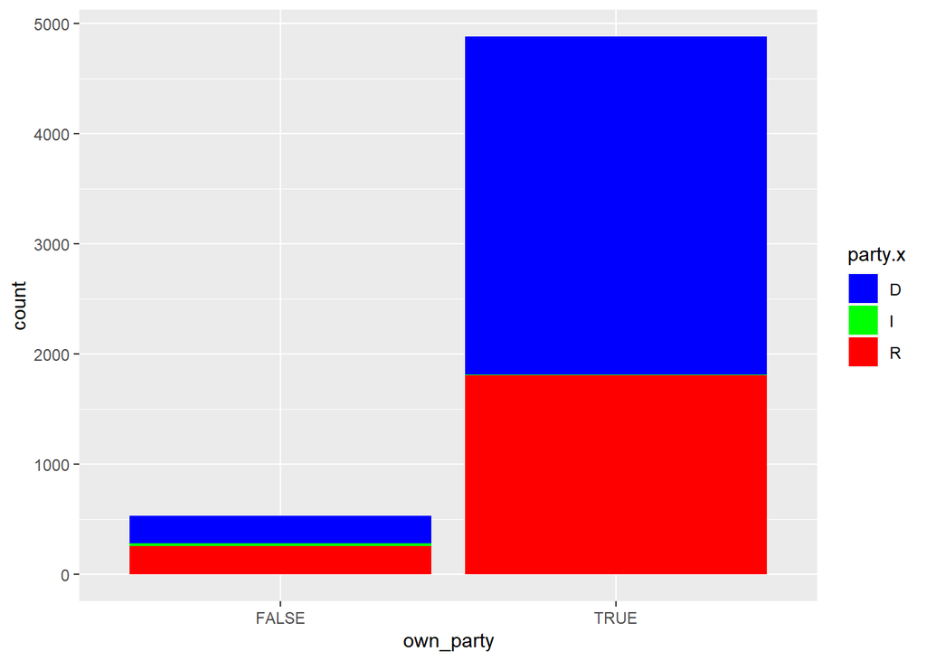

```r
ggplot(dt3, aes(x = own_party,  fill=party.x),position = "fill") +
  geom_bar( ) +
  scale_fill_manual(values = c("D" = "blue", "R" = "red","I"="green"))
```

```r
  labs(x = "Whether retweet source is own party ", y = "Number",
       title = "Retweet and party affiliation",
       caption = "Source: Twitter") +
theme_tufte()
```

2. Identifying Mentions Identify the tweets in which one senator mentions another senator directly (the variable is mentions_screen_name). For this example, please remove simple re-tweets (is_retweet == FALSE). Calculate who re-tweets whom among the senate members.

```r
dt4 <- dt %>% select(screen_name, is_retweet, mentions_screen_name)%>% filter(is_retweet == FALSE)
dt4 <- dt4[!is.na(dt4$mentions_screen_name),]
dt4 <- left_join(dt4,d_tw, by = c("screen_name"="twitter_handle"))
dt4 <- dt4 %>% unnest(mentions_screen_name)
dt4 <- left_join(dt4,d_tw, by = c("mentions_screen_name"="twitter_handle"))
dt4 <- dt4[!is.na(dt4$party.y),]
head(dt4)
```

```
## # A tibble: 6 x 9
##   screen_name is_retweet mentions_screen~ senator.x state.x party.x senator.y
##   <chr>       <lgl>      <chr>            <chr>     <chr>   <chr>   <chr>
## 1 SenatorBal~ FALSE      RonWyden         Baldwin,~ WI      D       Wyden, R~
## 2 SenatorBal~ FALSE      maziehirono      Baldwin,~ WI      D       Hirono, ~
## 3 SenatorBal~ FALSE      SenDuckworth     Baldwin,~ WI      D       Duckwort~
## 4 SenatorBal~ FALSE      SenStabenow      Baldwin,~ WI      D       Stabenow~
## 5 SenatorBal~ FALSE      SenBobCasey      Baldwin,~ WI      D       Casey, R~
## 6 SenatorBal~ FALSE      SenatorBraun     Baldwin,~ WI      D       Braun, M~
## # ... with 2 more variables: state.y <chr>, party.y <chr>
```

```r
dt4 <- rename(dt4, c("screen_name" = "source" ,"mentions_screen_name" = "target"))
head(dt4)
```

```
## # A tibble: 6 x 9
##   source  is_retweet target  senator.x state.x party.x senator.y state.y party.y
##   <chr>   <lgl>      <chr>   <chr>     <chr>   <chr>   <chr>     <chr>   <chr>
## 1 Senato~ FALSE      RonWyd~ Baldwin,~ WI      D       Wyden, R~ OR      D
## 2 Senato~ FALSE      mazieh~ Baldwin,~ WI      D       Hirono, ~ HI      D
## 3 Senato~ FALSE      SenDuc~ Baldwin,~ WI      D       Duckwort~ IL      D
## 4 Senato~ FALSE      SenSta~ Baldwin,~ WI      D       Stabenow~ MI      D
## 5 Senato~ FALSE      SenBob~ Baldwin,~ WI      D       Casey, R~ PA      D
## 6 Senato~ FALSE      Senato~ Baldwin,~ WI      D       Braun, M~ IN      R
```

```r
net3 <- dt4 %>% select(source, target)
gr3 <- graph_from_data_frame(d = net3, directed = FALSE)
V(gr3)$size <- centralization.degree(gr3)$res
E(gr3)$weight <- 1
g3 <- igraph::simplify(gr3, edge.attr.comb="sum")

set.seed(2103)
dat3 <- ggnetwork(g3,
          layout=igraph::with_fr(),
          )
```

```r
gg5 <- ggplot() +
  geom_edges(data=dat3,
             aes(x=x, y=y, xend=xend, yend=yend)) +
  geom_nodes(data=dat3,
             aes(x=x, y=y, xend=xend, yend=yend))
dat_top3 <- dat3 %>% distinct(name, .keep_all = TRUE)
dat3<- left_join(dat_top3,d_tw, by = c("name" = "twitter_handle"))
```

Convert the information to an undirected graph object in which the number of mentions is the strength of the relationship between senators. Visualize the network graph using the party identification of the senators as a group variable (use blue for Democrats and red for Republicans) and some graph centrality measure to size the nodes. Comment on what you can see from the visualization.

COmment: senators tend to mention members from own party. And independent senators interact more with dems.

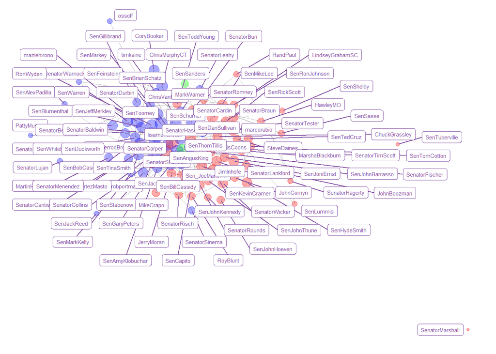

```r
(gg6 <- ggplot() +
    geom_edges(data=dat3,
               aes(x=x, y=y, xend=xend, yend=yend),
               color="grey50", curvature=0.1, size=0.15, alpha=1/2) +
    geom_nodes(data=dat3,
               aes(x=x, y=y, xend=xend, yend=yend,
                   size=size,colour = party),
               alpha=1/3) +
    geom_label_repel(data=dat_top3, max.overlaps = 100,
                     aes(x=x, y=y, label=name),
                     size=2, color="#8856a7") +
  scale_colour_manual(values = c("D" = "blue", "R" = "red","I"="green"))+
    theme_blank() +
    theme(legend.position="none") )
```

3. BONUS ONLY: Who is popular on Twitter? Using the twitter handles, access the user information of the senators to identify the number of followers they have (obviously, this will require to actually connect to the Twitter server). Re-do the previous graph object but now use the number of followers (or some transformation of that info) to size the nodes. Comment how graph degree centrality (via mentions) and the number of followers are related.